# Fox Evolution: A Demonstration Report

Simulated morphometric analysis of three fox species

Author

Affiliation

Radek Jaźwiec

Celon Pharma S.A.

Published

09-11-2026

**Warning**Demonstration document**

This report exists only to showcase the report format (title page, headers, numbering, cross-references, landscape pages, appendices, bibliography). All data are **simulated**, all references are **fictitious**, and no result has any scientific meaning. Photographs are taken from Wikimedia Commons under the licenses stated in the captions.

# 1 Summary

Three fox species (red, Arctic and fennec fox) were compared on simulated morphometric data from 150 specimens collected at 6 sites and spanning the last 3.5 million years (Ma). Body mass changed by -3.4% per million years of specimen age in the red fox, and ear length increased by 0.13 cm per °C of mean annual temperature (Section 4). Lineage accumulation differed between three fictional clades (Figure 5). The description is exploratory and purely illustrative.

# 2 Introduction

## 2.1 Background

Foxes are small to medium-sized members of the family Canidae and occupy habitats from Arctic tundra to hot desert [1]. Their appendages are a textbook illustration of adaptation to ambient temperature: large ears in the fennec fox dissipate heat, whereas the compact ears of the Arctic fox conserve it [2]. Figure 1 shows a historical painting of common foxes in a winter landscape.

[figure not shown]

Figure 1: Common foxes in the snow. Painting by Wilhelm Kuhnert (public domain, Wikimedia Commons).

## 2.2 Objectives

The objectives of this demonstration analysis were to

1. describe the change of body mass over geological time,
2. relate ear length to mean annual temperature, and
3. compare the accumulation of lineages between clades.

# 3 Methods

## 3.1 Specimens and data sources

Specimen records were simulated for three species (Table 1). Each record holds the site, the specimen age, the mean annual temperature at the site and time of deposition, and five morphometric measurements[^1]. Sampling bias is a known problem of fossil data [3] and is ignored here.

Table 1: Simulated specimens by species: number of specimens, age range, and mean (SD) of body mass and ear length.

| Common name | Species | Habitat | N | Age range (Ma) | Body mass (kg) | Ear length (cm) |
| --- | --- | --- | --- | --- | --- | --- |
| Red fox | *Vulpes vulpes* | Temperate woodland | 60 | 0.1–3.5 | 6.23 (0.53) | 9.9 (0.7) |
| Arctic fox | *Vulpes lagopus* | Arctic tundra | 45 | 0.1–3.5 | 3.36 (0.30) | 7.1 (0.8) |
| Fennec fox | *Vulpes zerda* | Hot desert | 45 | 0.2–3.3 | 1.12 (0.09) | 15.5 (0.7) |

Values are arithmetic mean (standard deviation).

## 3.2 Statistical analysis

Body mass $m$ of specimen $j$ of species $s$ was modeled on the log scale as a linear function of specimen age $t$,

$$\log m_{sj} = \beta_{0,s} + \beta_{1,s}\, t_{sj} + \varepsilon_{sj},
\qquad \varepsilon_{sj} \sim N(0, \sigma^2),
\tag{1}$$

and ear length was modeled analogously on mean annual temperature. Both models contain a species-specific intercept and slope (details in Section 8). Lineages through time were simulated as a pure-birth process [4]. Skull shape scores were derived as described by [5].

**Note**

All p-values are descriptive. No hypothesis was specified in advance, so no multiplicity adjustment was made.

# 4 Results

## 4.1 Body mass through time

Body mass was highest in the red fox and lowest in the fennec fox, with a slight increase towards the present in all three species (Figure 2). On the log scale the red fox slope was -0.035 per million years (Table 3).

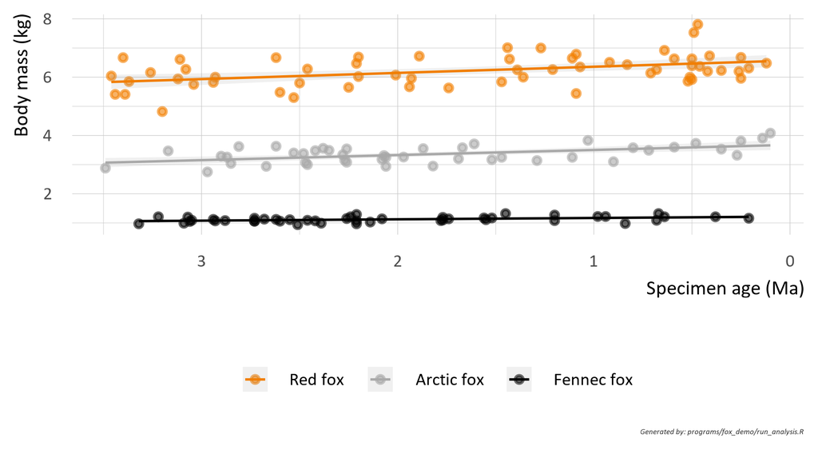

Figure 2: Body mass by specimen age and species with linear fit and 95% confidence band.

## 4.2 Ear size and climate

Ear length increased with mean annual temperature in every species (Figure 3), in line with the heat-dissipation argument of [2]. The fennec fox (Figure 4) had the longest ears at every temperature.

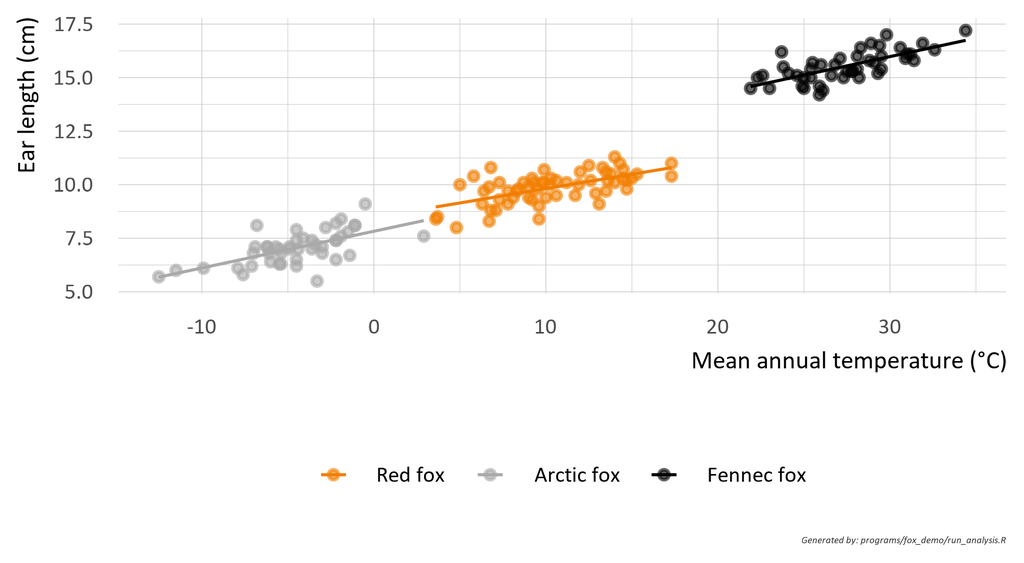

Figure 3: Ear length by mean annual temperature and species with linear fit.

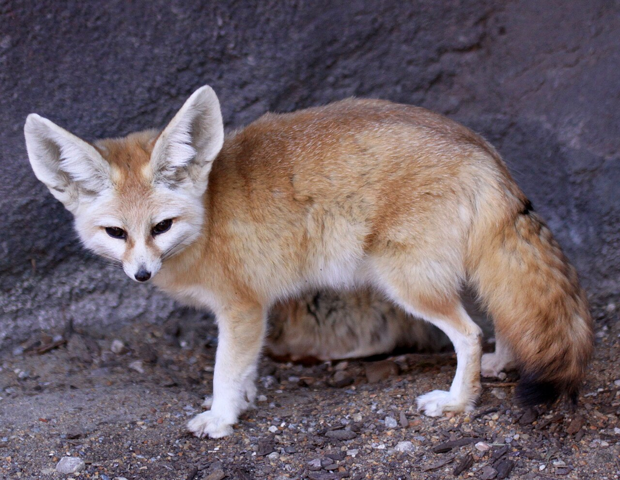

Figure 4: Fennec fox (*Vulpes zerda*). Photograph by Drew Avery, CC BY 2.0, Wikimedia Commons.

## 4.3 Diversification

The three fictional clades accumulated lineages at different rates (Figure 5). Clade I, the fastest, accumulated the most lineages, whereas Clade III grew only modestly.

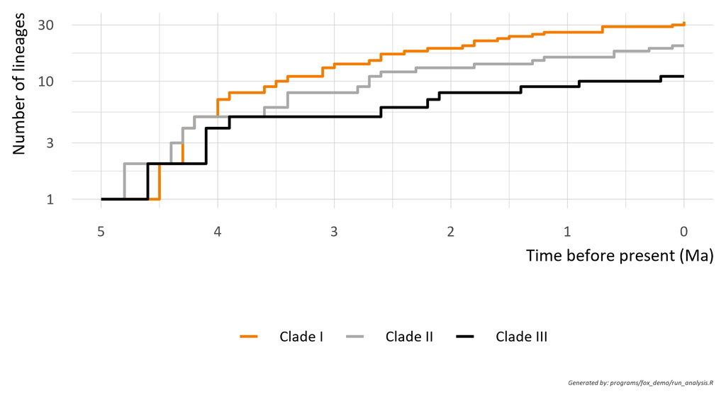

Figure 5: Lineages through time (log scale) for three fictional clades.

## 4.4 Specimen-level data

Table 2 lists a selection of specimens with all measurements. The table occupies a full landscape page; the page orientation returns to portrait after it.

Table 2: Selection of simulated specimens (eight per species) with provenance, context and morphometric data.

| Specimen | Provenance Site | Provenance Region | Provenance Latitude (°N) | Context Age (Ma) | Context Temp. (°C) | Morphometrics Body mass (kg) | Morphometrics Ear (cm) | Morphometrics Skull (cm) | Morphometrics Tail (cm) | Morphometrics Hind foot (cm) | Shape scores Score 1 | Shape scores Score 2 |
| --- | --- | --- | --- | --- | --- | --- | --- | --- | --- | --- | --- | --- |
| Red fox |  |  |  |  |  |  |  |  |  |  |  |  |
| FX-001 | Site E | Arabia | 25 | 2.20 | 14.7 | 6.69 | 9.8 | 13.0 | 55.8 | 16.8 | 1.43 | 0.93 |
| FX-002 | Site A | Northern Europe | 58 | 1.11 | 12.5 | 6.65 | 10.9 | 12.8 | 53.4 | 16.1 | 1.45 | 0.52 |
| FX-003 | Site A | Northern Europe | 58 | 0.92 | 9.9 | 6.51 | 10.7 | 13.1 | 54.0 | 15.7 | 0.78 | 0.57 |
| FX-004 | Site F | Alaska | 65 | 2.93 | 14.0 | 6.00 | 10.1 | 11.8 | 57.1 | 15.7 | 0.72 | 1.71 |
| FX-005 | Site E | Arabia | 25 | 0.50 | 9.2 | 6.63 | 10.3 | 13.3 | 54.6 | 16.2 | 1.31 | 0.30 |
| FX-006 | Site C | Greenland | 72 | 0.12 | 5.0 | 6.48 | 10.0 | 12.7 | 56.1 | 16.4 | 1.20 | 0.92 |
| FX-007 | Site D | Sahara | 24 | 1.44 | 6.7 | 7.01 | 9.9 | 12.9 | 56.4 | 17.1 | 0.88 | 0.46 |
| FX-008 | Site D | Sahara | 24 | 1.39 | 9.2 | 6.25 | 9.3 | 12.7 | 53.9 | 16.8 | 1.33 | 0.62 |
| Arctic fox |  |  |  |  |  |  |  |  |  |  |  |  |
| FX-061 | Site D | Sahara | 24 | 2.87 | −1.4 | 3.26 | 6.7 | 10.7 | 45.6 | 13.1 | −0.71 | 0.53 |
| FX-062 | Site A | Northern Europe | 58 | 2.07 | −4.5 | 3.31 | 6.5 | 10.2 | 46.4 | 13.9 | −1.51 | −0.13 |
| FX-063 | Site F | Alaska | 65 | 1.82 | −3.3 | 2.95 | 5.5 | 9.9 | 46.6 | 14.5 | −1.07 | 0.15 |
| FX-064 | Site D | Sahara | 24 | 2.85 | −0.5 | 3.04 | 9.1 | 9.9 | 48.2 | 14.7 | −0.95 | 0.63 |
| FX-065 | Site A | Northern Europe | 58 | 1.11 | −3.4 | 3.25 | 7.2 | 10.4 | 44.7 | 14.1 | −1.14 | −0.96 |
| FX-066 | Site A | Northern Europe | 58 | 0.14 | −12.5 | 3.91 | 5.7 | 11.2 | 49.1 | 14.5 | −0.83 | 0.51 |
| FX-067 | Site D | Sahara | 24 | 0.27 | −7.9 | 3.32 | 6.1 | 10.2 | 47.2 | 13.6 | −1.74 | 0.43 |
| FX-068 | Site F | Alaska | 65 | 2.38 | −6.0 | 3.56 | 6.4 | 10.5 | 45.8 | 13.6 | −0.91 | 0.02 |
| Fennec fox |  |  |  |  |  |  |  |  |  |  |  |  |
| FX-106 | Site B | Siberia | 68 | 3.07 | 31.9 | 1.20 | 16.6 | 7.4 | 37.8 | 11.1 | −0.54 | −0.07 |
| FX-107 | Site A | Northern Europe | 58 | 2.68 | 27.1 | 1.13 | 15.9 | 7.6 | 33.9 | 10.7 | −0.64 | −1.90 |
| FX-108 | Site D | Sahara | 24 | 0.64 | 23.8 | 1.21 | 15.5 | 7.6 | 33.1 | 11.3 | −0.49 | −2.58 |
| FX-109 | Site B | Siberia | 68 | 3.09 | 25.4 | 0.99 | 15.0 | 6.8 | 33.6 | 10.4 | −1.50 | −2.06 |
| FX-110 | Site D | Sahara | 24 | 2.21 | 24.9 | 0.97 | 14.6 | 7.0 | 34.6 | 10.3 | −1.07 | −1.32 |
| FX-111 | Site E | Arabia | 25 | 3.05 | 25.0 | 1.09 | 14.5 | 7.7 | 32.5 | 10.9 | −1.16 | −2.09 |
| FX-112 | Site B | Siberia | 68 | 2.73 | 28.1 | 1.16 | 16.0 | 6.9 | 36.0 | 10.6 | −1.16 | −0.05 |
| FX-113 | Site D | Sahara | 24 | 2.26 | 31.4 | 1.15 | 15.8 | 7.6 | 36.5 | 11.8 | −0.20 | −0.78 |

Skull shape scores are standardized (mean 0, SD 1) over all specimens.

# 5 Discussion

The simulated data reproduce the qualitative pattern expected from the literature: larger bodies in the temperate species, and longer ears in warmer climates. The effect sizes carry no information because the data were generated from the same equations that were used to analyze them.

## 5.1 Limitations

- The data are fictional.
- Specimen age was drawn independently of site, so no spatial structure exists.
- The lineage process ignores extinction.

# 6 Conclusions

This document demonstrates numbered sections and subsections, cross-references to figures, tables, equations and appendices, a landscape page, separately numbered appendices, a bibliography and tables of contents, tables and figures.

# 7 References

1.

Reynard AB, Vulpine CD (2019) Body mass trajectories of canid lineages across the pleistocene: A simulation framework. Journal of Fictional Zoology 41(3):211–230. https://doi.org/10.0000/jfz.2019.0411

2.

Vulpine CD, Brush TE, Kitsune H (2021) Appendage size and ambient temperature in small carnivores revisited. Annals of Imaginary Mammalogy 12(1):45–67. https://doi.org/10.0000/aim.2021.0012

3.

Tod FG, Reynard AB (2015) Sampling bias in the fossil record of medium-sized carnivores. Journal of Fictional Zoology 37(2):101–119. https://doi.org/10.0000/jfz.2015.0372

4.

Kitsune H, Reynard AB (2023) Diversification rates of fox-like canids under a pure-birth model. Proceedings of the Society for Hypothetical Evolution 290(1998):20230101. https://doi.org/10.0000/pshe.2023.0101

5.

Brush TE (2017) Geometric morphometrics of vulpine skulls: An invented handbook. Tundra University Press, Nowhere

# 8 Appendix 1 - Model details

## 8.1 Body mass model

Table 3: Coefficients of the log body mass model (Equation 1). Reference species: red fox.

| Term | Estimate | Std. error | t value | p value |
| --- | --- | --- | --- | --- |
| Intercept (Red fox) | 1.881 | 0.018 | 106.299 | <0.0001 |
| Age (Red fox) | −0.035 | 0.009 | −3.819 | 0.0002 |
| Arctic fox (offset) | −0.580 | 0.031 | −18.544 | <0.0001 |
| Fennec fox (offset) | −1.687 | 0.035 | −48.413 | <0.0001 |
| Age × Arctic fox | −0.017 | 0.016 | −1.075 | 0.2840 |
| Age × Fennec fox | −0.006 | 0.016 | −0.360 | 0.7193 |

## 8.2 Ear length model

Table 4: Coefficients of the ear length model on mean annual temperature. Reference species: red fox.

| Term | Estimate | Std. error | t value | p value |
| --- | --- | --- | --- | --- |
| Intercept (Red fox) | 8.478 | 0.242 | 35.035 | <0.0001 |
| Temperature (Red fox) | 0.134 | 0.022 | 6.013 | <0.0001 |
| Arctic fox (offset) | −0.652 | 0.291 | −2.243 | 0.0264 |
| Fennec fox (offset) | 2.326 | 0.849 | 2.740 | 0.0069 |
| Temperature × Arctic fox | 0.037 | 0.037 | 0.998 | 0.3200 |
| Temperature × Fennec fox | 0.039 | 0.037 | 1.044 | 0.2983 |

## 8.3 Skull shape

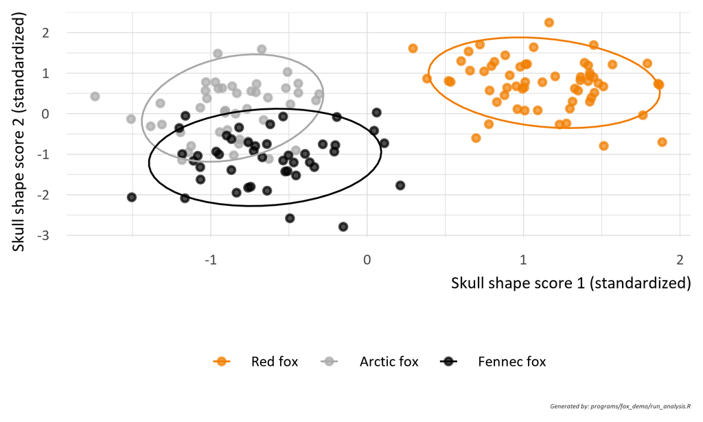

Figure 6: Skull shape scores 1 and 2 by species with 90% data ellipses.

# 9 Appendix 2 - Sampling and diagnostics

## 9.1 Sampling sites

Specimens came from the sites listed in Table 5. Figure 7 shows a museum specimen of the Arctic fox.

Table 5: Number of simulated specimens by site and species.

| Site | Region | Latitude (°N) | Red fox | Arctic fox | Fennec fox | Total |
| --- | --- | --- | --- | --- | --- | --- |
| Site A | Northern Europe | 58 | 9 | 10 | 8 | 27 |
| Site B | Siberia | 68 | 10 | 2 | 11 | 23 |
| Site C | Greenland | 72 | 8 | 6 | 6 | 20 |
| Site D | Sahara | 24 | 10 | 10 | 9 | 29 |
| Site E | Arabia | 25 | 18 | 10 | 8 | 36 |
| Site F | Alaska | 65 | 5 | 7 | 3 | 15 |

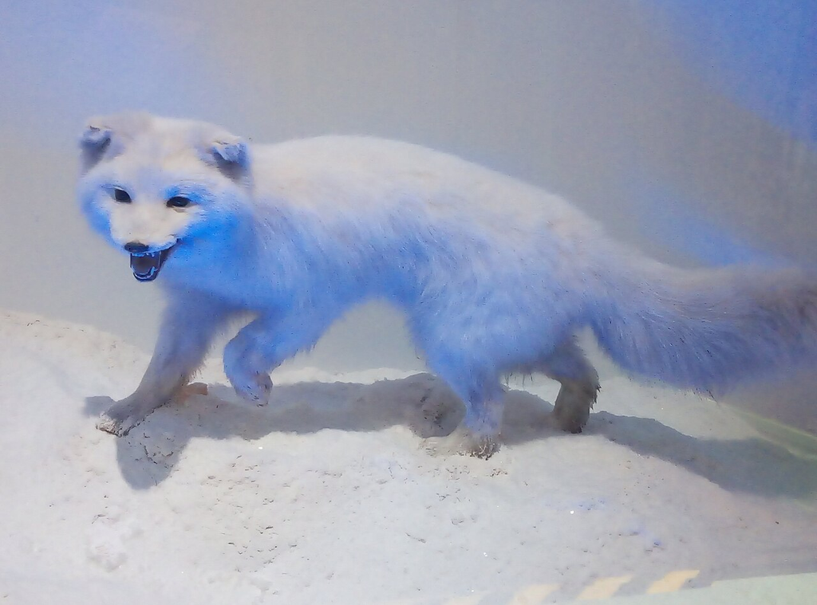

Figure 7: Arctic fox specimen at a natural history museum. Photograph by the World Museum vertebrate zoology curator, CC0, Wikimedia Commons.

## 9.2 Model diagnostics

Figure 8 shows the residuals of the body mass model, and Table 6 the sample size and mean body mass per age class.

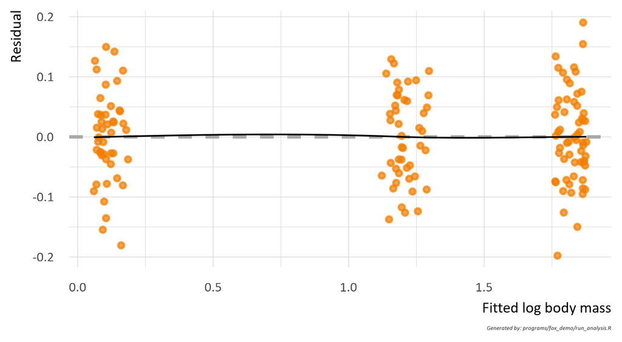

Figure 8: Residuals versus fitted values of the log body mass model.

Table 6: Number of specimens and mean body mass (kg) by age class and species.

| Age class (Ma) | Red fox N | Red fox Mean mass | Arctic fox N | Arctic fox Mean mass | Fennec fox N | Fennec fox Mean mass |
| --- | --- | --- | --- | --- | --- | --- |
| 0–1 | 22 | 6.46 | 10 | 3.62 | 8 | 1.18 |
| 1–2 | 15 | 6.28 | 11 | 3.35 | 10 | 1.16 |
| 2–3 | 12 | 6.02 | 22 | 3.26 | 21 | 1.09 |
| 3–3.5 | 11 | 5.90 | 2 | 3.17 | 6 | 1.08 |

## Footnotes

[^1]: Body mass, ear length, skull length, tail length and hind foot length.